# R Tutorial for CA 5b: Using the R Shiny app Power Simulator

Authors: Timothy Reese, Halin Shin STAT 350

# 1 Introduction to R Shiny

[figure not shown]

Shiny is an open source R package that provides an elegant and powerful framework for building web applications using R language. You can explore examples of web applications created using Shiny in https://www.rstudio.com/products/shiny/.

Shiny is a perfect tool to get a better understanding of concepts such as confidence interval (CI). A confidence interval comes with many components which play distinct roles in determining its properties. In this assignment, the interactive feature of Shiny will allow you to experiment with various choices of each component and observe how the intervals change.

An R Shiny project can be embedded into a website and shared through its URL, or it can be rendered by your own RStudio by running the source code. This tutorial will walk you through the latter method.

# 2 Running an R Shiny file

**Important Note**: Scholar is experiencing technical difficulties with running Shiny Apps on R version 4.2.2. Please switch to R version 4.3.1. when running Shiny Apps on Scholar.

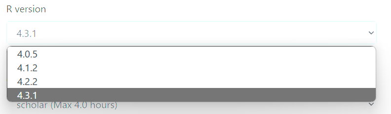

## Step 1: locate the file

#### Local RStudio users

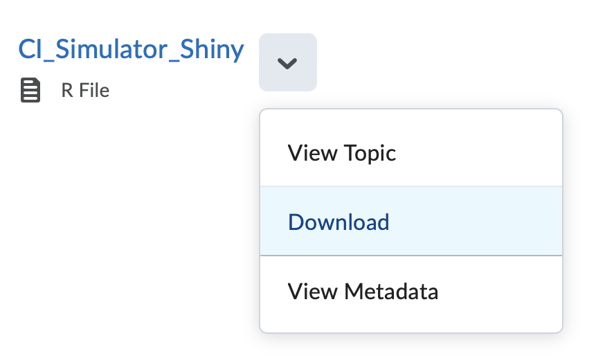

Download the file from Brightspace to a convenient directory on your computer.

#### Scholar users

Locate the Shiny App file in the same shared folder where all class materials are saved, in `/depot/statclass/data/stat35000/2024SPRING`.

## Step 2: open the file on RStudio

[figure not shown]

On the upper left corner of RStudio, click `File`, then `Open File...`.

#### Local RStudio users

Go to the location of the file, then click `Open`.

#### Scholar users

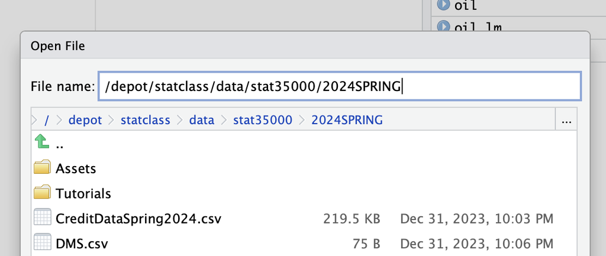

Go to the course folder by pasting the directory to the text box then clicking `Open`. Find and click the file in the list, then click `Open` again.

**Once the file is open, be careful not to change anything in the source code.**

## Step 3: install required packages

An R Shiny file opens as a regular R script. You must first make sure all the necessary packages required by the file are installed on your copy of R/RStudio. The file `CI_Simulator_Shiny.R` uses three packages, `shiny`,`ggplot2`, and `gridExtra`.

`ggplot2` should already be installed in your RStudio from previous computer assignments. To install the other two, run `install.packages("shiny")` and `install.packages("gridExtra")` in the console. You can also do this in one line of code, using `install.packages(c("shiny", "gridExtra"))`.

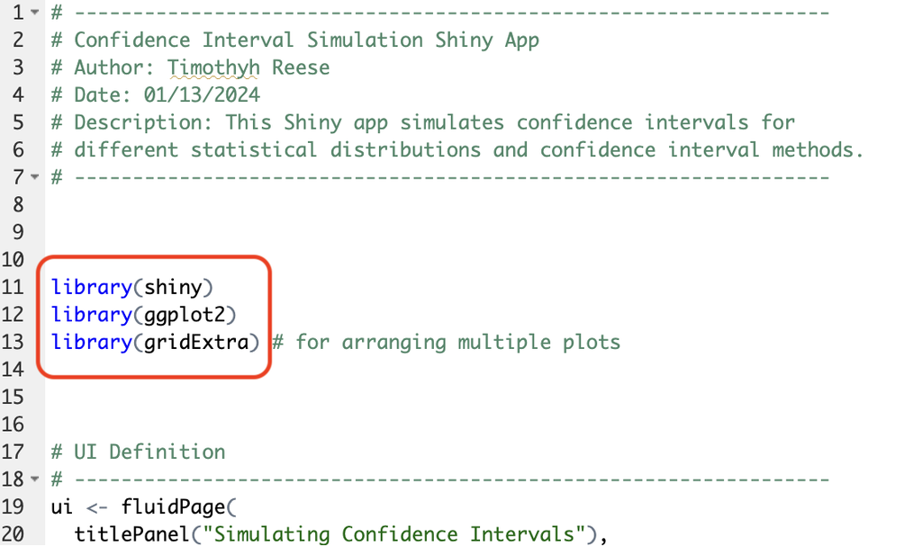

In general, it is customary to list the loading command `library()` of all external packages at the beginning of a script. When using an R Shiny app, or any other R script written by others, check the first lines to see if you need to install any packages.

## Step 4: run the app

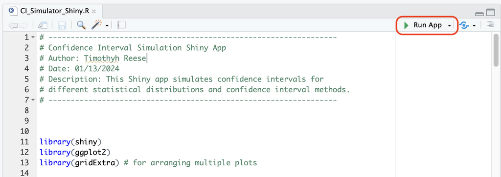

Click `Run App` in the upper right corner of the script window.

## Step 5: you are ready to use the app

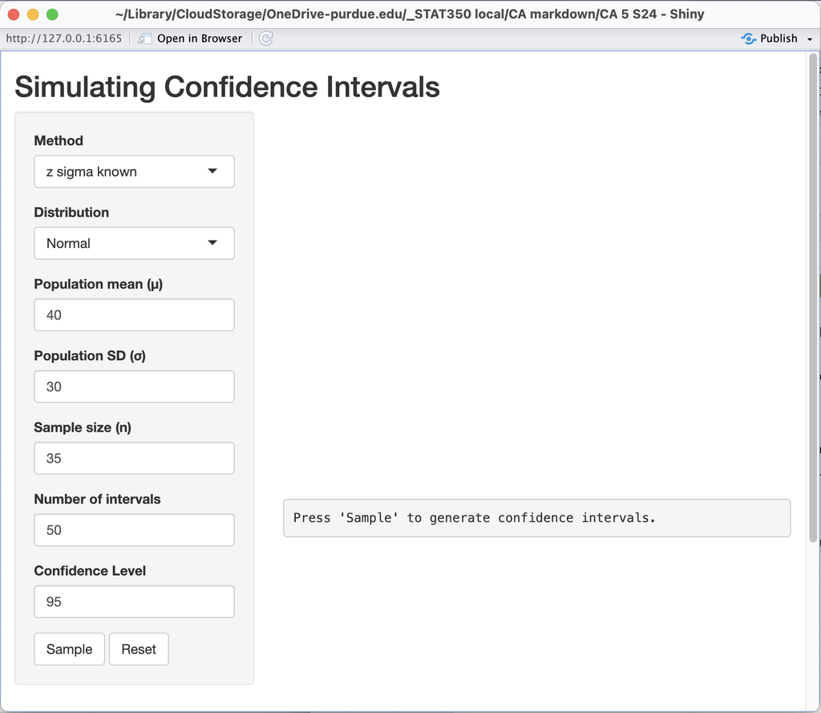

A new window will open containing the rendered app.

# 3 Exploring Statistical Power with the Power Analysis Visualization Applet

You will explore the factors affecting statistical power and error rates using the Power Analysis Visualization Applet. You will manipulate the mean values under null and alternative hypotheses, adjust the significance level (alpha), vary sample sizes, and observe the impact of these changes on Power, Type I and Type II errors.

## Setting Parameters

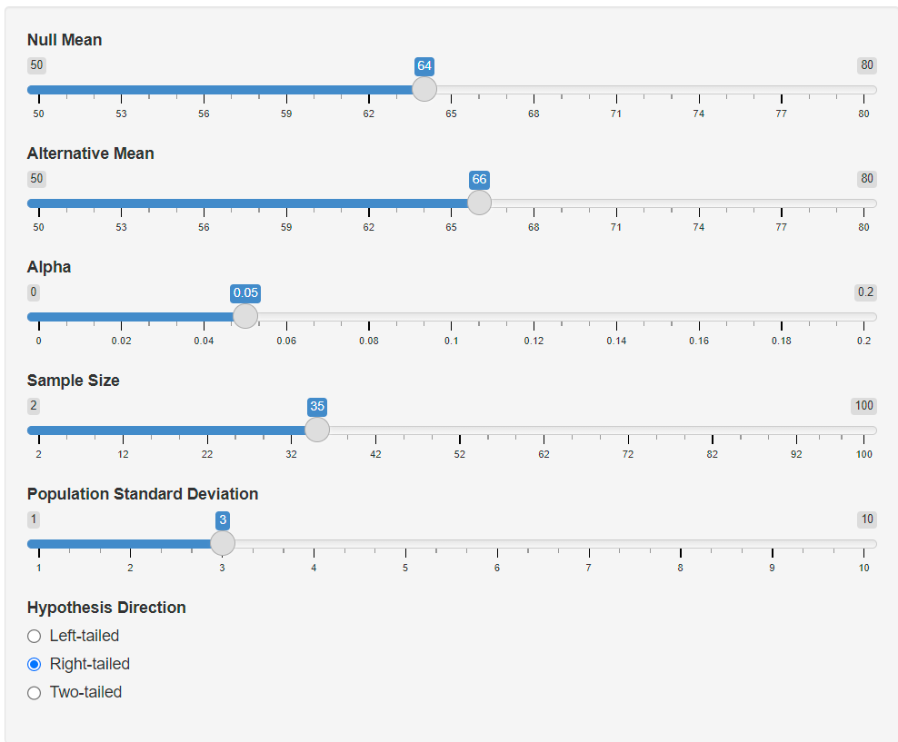

- **Null Mean**: Set the assumed population mean when the null hypothesis is true (no effect).
- **Alternative Mean**: Set the expected population mean under the alternative hypothesis (presence of effect).
- **Alpha ($\alpha$)**: Set the Type I error rate, the probability of rejecting the null hypothesis when it is actually true.
- **Sample Size ($n$)**: Choose the number of observations that would be sampled.
- **Population Standard Deviation ($\sigma$)**: Select the population’s standard deviation, which is assumed to be the same under both the null and alternative hypotheses.
- **Hypothesis Direction**: Choose the direction for the hypothesis test:
  - **Left-tailed**: Use when the alternative hypothesis mean is expected to be less than the null hypothesis mean.
  - **Right-tailed**: Use when the alternative hypothesis mean is expected to be greater than the null hypothesis mean.
  - **Two-tailed**: Use when the alternative hypothesis mean could be either less than or greater than the null hypothesis mean.

After setting your parameters, the plots will automatically be updated.

## Interpreting Results

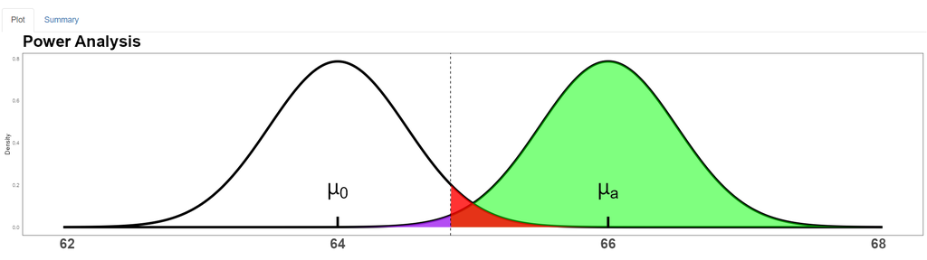

The main panel will display two distinct normal distribution curves corresponding to the null and alternative hypothesis means, each clearly annotated. The area shaded in green represents the power of the test, indicating the likelihood of correctly rejecting the null hypothesis when it is false. The red shaded area denotes the Type I error, the probability of erroneously rejecting a true null hypothesis, while the purple shaded area signifies the Type II error, the chance of failing to reject a false null hypothesis.

## Key Observations for Students

You are encouraged to explore and note significant insights and takeaways from the Power Analysis Visualization Applet. Pay close attention to how changes in the input parameters affect the shaded regions and the shape of the distributions. Key observations may include:

- The impact of altering the null and alternative mean values on the power of the test and the positioning of the distribution curves.
- The relationship between the alpha level and the size of the red shaded region, which represents the Type I error rate.
- How variations in sample size influence the green shaded region, reflecting the test’s power, and the standard error of the distribution.
- The effect of changing the population standard deviation on the spread of the distribution curves and the subsequent error rates.
- The implications of selecting different hypothesis directions (left-tailed, right-tailed, two-tailed) on the critical value cutoffs and shaded error regions.
- Use these observations to deepen your understanding of statistical hypothesis testing, specifically how each factor contributes to the probability of making correct or incorrect inferences about the population based on sample data.